# DSP Analysis and summary 2025

25 July 2025

# Overview of experiment and analyses

This is the complete analysis of the DSP task using white matter and bevaior and hormones.

# Methods

## **Scan parameters**

- Locations from UCSB and UCI

## **QSIprep**

- Version used: 0.16.0RC3
- The following parameters were used
  - dwi_denoise_window **5**
  - hmc_model **3dSHORE**
  - hmc-transform **Rigid**
  - shoreline_iters **2**

## **DSI Studio**

- Version and tags used via singularity container: **chen-2024-05-03**
- **Parameters**
  - T-threshold = 2.5
  - Length = 25
  - Permutation = 4,000
  - pruning 4
  - QA
  - Covariates: sex, age, and FNAME

## **Hormones and behavior**

I am doing a mediation analysis to understand the relation ship between white matter, hormones, and performance on the dual solution paradigm.

From shuying’s data, DSP is associated with estradial. Increased solution index is associated with increased solution index.

MD is negatively associated with Solution Index such that increased MD in the fornix is associated with less shortcuts. Essentially lower white matter integrity in fornix is associated with lower performance.

Hypothesis for mediation is that greater estradiol is driving the relationship in which greater integrity in the fornix for greater solution index.

X= Mean diffusivity in fornix  
Y= greater SI on DSP task  
M= Estradiol

**Subject Numbers for DSP analyses** Total SNAG numbers: 137  
* 60 removed Total participants with DSP: 77 Total participants with DSI scans: 73 Total participants used in analyses: 69

Shuyings numbers are as follows from her behavioral task, idk who she excluded:  
Women: 47  
MEn:28  
Total:75

Daniela’s

Women: 45  
Men: 23  
Total: 68

Subjects I excluded 347 for Low quality outliar 424 for low quality outliar 372 for neurochistosomaisis 388 for cyst in cerebellum 352 for depression

These were excluded later from hippocampal analyses so i just excluded their behavior here as well. Adding these in gives me 77 which is still not the correct number of subjects. I’m not sure which one is the extra. For now I’ll add them back in but it shouldn’t affect much.

# Reading in and prepping our data

```r
working_dir <- "/Users/danielacossio/Documents/Chrastil_Lab/Projects/SNAG/DSI/DSP"

rows2grab <- c("Tract Name", "number of tracts","mean length(mm)","span(mm)", "total volume(mm^3)")

behavior_sub_info <- read.csv("/Users/danielacossio/Documents/Chrastil_Lab/Projects/SNAG/sub_info_sheets/SNAG_Behavior.csv") # This is a sheet that has all of the subjects with at least one usable behavior task (Loop, maze, dsp). Filtering 352 here because i didn't manually exclude in this sheet

DSP_DSI_DF <- read.csv("/Users/danielacossio/Documents/Chrastil_Lab/Projects/SNAG/sub_info_sheets/DSPDSI.csv") %>% filter(!is.na(subject_id)) %>%  filter(subject_id != 352) # This is from the main subject sheet and includes all subjects that have a dsp score AND should have a scan with them


path2tractometry <- ("/Users/danielacossio/Documents/Chrastil_Lab/Projects/SNAG/DSI/Tractometry/output")

# sub_info <- read.csv("/Users/danielacossio/Documents/Chrastil_Lab/Projects/subject_info.csv") # I dont think this one is necessary

# List of all subject directories
tractometry_subfiles <- list.dirs("/Users/danielacossio/Documents/Chrastil_Lab/Projects/SNAG/DSI/Tractometry/output", full.names = FALSE,recursive = FALSE)

f_data_dsp <- DSP_DSI_DF %>% filter(sex == "Female")
m_data_dsp<- DSP_DSI_DF %>% filter(sex=="Male")

Behavioronly_data_dsp <- behavior_sub_info %>% filter(dsp_useable == "Yes") %>% filter(subject_id < 500) # dataframe with all subjects that have usable DSP

Behavioronly_Female_data_dsp <- behavior_sub_info %>% filter(dsp_useable == "Yes") %>% filter(subject_id < 500) %>%  filter(sex=="Female")


#This is going through and reading in the output from dsi studio and then combining it into one dataframe and then combining that with our data frame that contains our subject data.

# create an empty dataframe to loop into
fornix_output_df <-  data.frame(matrix(ncol = 5, nrow = 0)) %>% `colnames<-`(c("subjects","QA_L_fornix","QA_R_fornix","MD_L_fornix","MD_R_fornix"))

# creating a loop to go into each sub dir. read in each txt file and extract the
for(file in 1:length((tractometry_subfiles))){


  # creating an empty single row dataframe
  empty_loop_df <- data.frame(matrix(ncol = 5, nrow = 1))  %>% `colnames<-`(c("subjects","QA_L_fornix","QA_R_fornix","MD_L_fornix","MD_R_fornix"))

  # inputting the subject id
  empty_loop_df$subjects <- str_remove(tractometry_subfiles[file],"sub-")


  # Let's do a quick folder check to make sure it's not empty


  if(file.size(paste0(path2tractometry,"/",tractometry_subfiles[file])) < 96) next

  #grabbing all the left and right variables

  if (file.exists(paste0(path2tractometry,"/",tractometry_subfiles[file],"/",tractometry_subfiles[file],"_space-T1w_desc-preproc_dwi.ProjectionBasalGanglia_FornixL.stat.txt")) == FALSE) {
    L_fornix <- data.frame(matrix(ncol = 2, nrow = 2))
  } else{
    L_fornix <- read_delim(paste0(path2tractometry,"/",tractometry_subfiles[file],"/",tractometry_subfiles[file],"_space-T1w_desc-preproc_dwi.ProjectionBasalGanglia_FornixL.stat.txt"),col_names = FALSE) %>% filter(X1 %in% c("qa","md"))
  }


  if (file.exists(paste0(path2tractometry,"/",tractometry_subfiles[file],"/",tractometry_subfiles[file],"_space-T1w_desc-preproc_dwi.ProjectionBasalGanglia_FornixR.stat.txt")) == FALSE) {
    R_fornix <- data.frame(matrix(ncol = 2, nrow = 2))
  }else{

  R_fornix <- read_delim(paste0(path2tractometry,"/",tractometry_subfiles[file],"/",tractometry_subfiles[file],"_space-T1w_desc-preproc_dwi.ProjectionBasalGanglia_FornixR.stat.txt"),col_names = FALSE) %>% filter(X1 %in% c("qa","md"))
  }

  # Putting them into out dataframe
  #Grab all QA values
  empty_loop_df$QA_L_fornix <- L_fornix$X2[1] # row 1 is QA
  empty_loop_df$QA_R_fornix <- R_fornix$X2[1]


  empty_loop_df$MD_L_fornix <- L_fornix$X2[2] # row 2 is MD
  empty_loop_df$MD_R_fornix <- R_fornix$X2[2]

  fornix_output_df <- rbind(fornix_output_df,empty_loop_df)
}


# now we have to grab the information from sub info and combine but we need to make sure we're grabbing all the correct subjects from each dataframe. Something to note is that this final fornix data frame is based off of scans and includes some people who do not have a DSP score. There's probably a way to simplify the code below.

altered_sub_info <- DSP_DSI_DF %>% filter(subject_id %in% c(fornix_output_df$subjects))

fornix_output_df <- fornix_output_df %>%  filter(subjects %in% c(DSP_DSI_DF$subject_id))


clean_DF <- cbind(altered_sub_info,fornix_output_df)

clean_DF$QA_Whole_Fornix <- rowMeans(clean_DF[,c("QA_L_fornix","QA_R_fornix")])

clean_DF$MD_Whole_Fornix <- rowMeans(clean_DF[,c("MD_L_fornix","MD_R_fornix")])


all_women_clean_df <- clean_DF %>% filter(sex=="Female")
all_men_clean_df <- clean_DF %>% filter(sex=="Male")
```

Below is a list of important variables:  
* working_dir : path directory to main working directory  
* rows2grab : information to grab from tables  
* behavior_sub_info : All SNAG subjects including those that do not have DSP score. this is straight raw data * DSP_DSI_DF : CSV that specifically have DSP score and a scan with them * f_data_dsp: female only from DSP_DSIDF frame. scan and DSP * path2tractometry  
* sub_info  
* tractometry_subfiles  
* clean_DF : this is a data frame with all the tractometry results. only 54 of subjects were able to have tractometry performed but I might manually run things to see if i can extract.  
* Behavioronly_data_dsp : behavior scans removing 372,388,352 * Behavioronly_Female_data_dsp: behavior scans for women only. Shuyings analyses number

# Behavior and Hormones

## Step 1: Normality check and visualization of data

### DSP distribution & Normality (behav only)

Here I am plotting the data for all dsp(regardless of scan). There are a total of 74 subjects here. Shuying had about 76/77 subjects and i noted the Discrepancy above. I removed 372,388, 352. Shuying probably did not exclude 388.

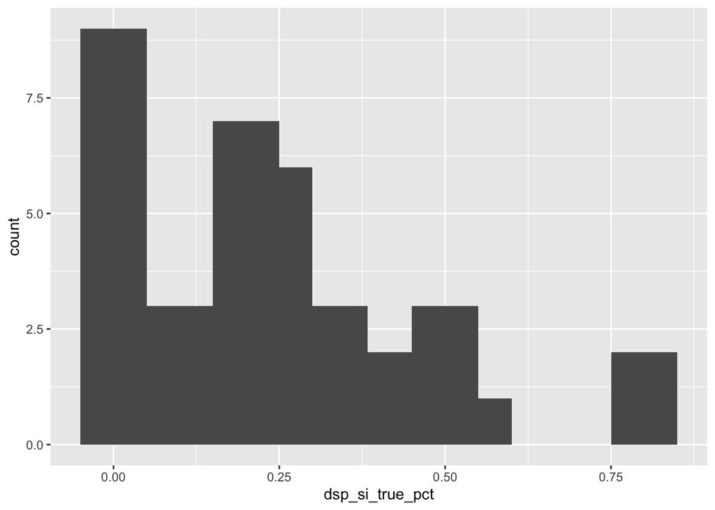

```r
ggplot(Behavioronly_data_dsp,aes(x=dsp_si_true_pct)) +
   geom_bar(width = 0.1)
```

```r
shapiro.test(DSP_DSI_DF$dsp_si_true_pct)
```

```
##
##  Shapiro-Wilk normality test
##
## data:  DSP_DSI_DF$dsp_si_true_pct
## W = 0.9189, p-value = 0.0002913
```

Here, I am checking skew using the dataframe that lists all subjects with a scan and DSP score. This brings us to 68 subjects. You can see there is a right hand skew on this data and it does not pass normality test (p-value = 0.0002913).

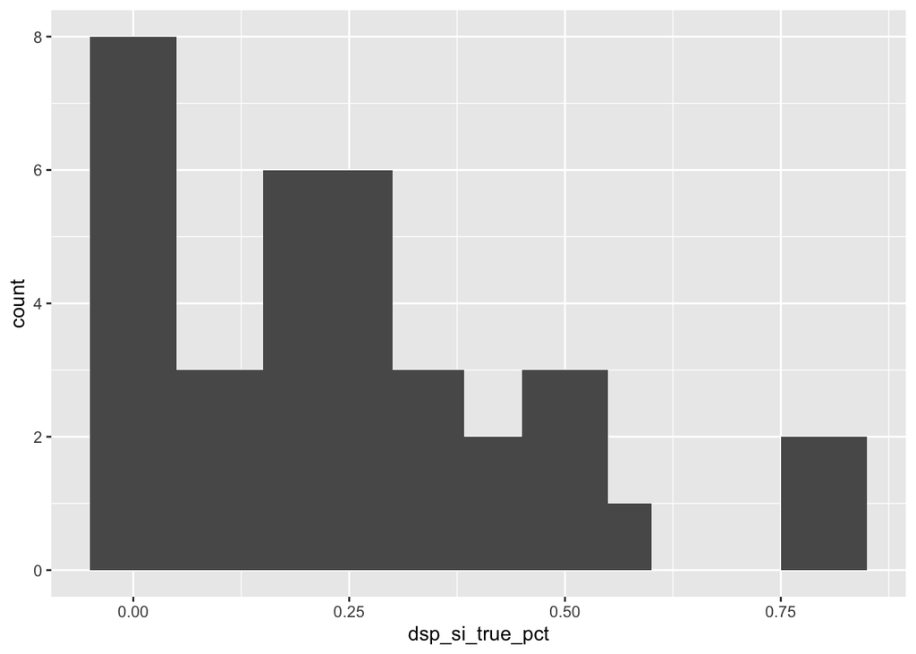

```r
ggplot(DSP_DSI_DF,aes(x=dsp_si_true_pct)) +
   geom_bar(width = 0.1)
```

```r
shapiro.test(DSP_DSI_DF$dsp_si_true_pct)
```

```
##
##  Shapiro-Wilk normality test
##
## data:  DSP_DSI_DF$dsp_si_true_pct
## W = 0.9189, p-value = 0.0002913
```

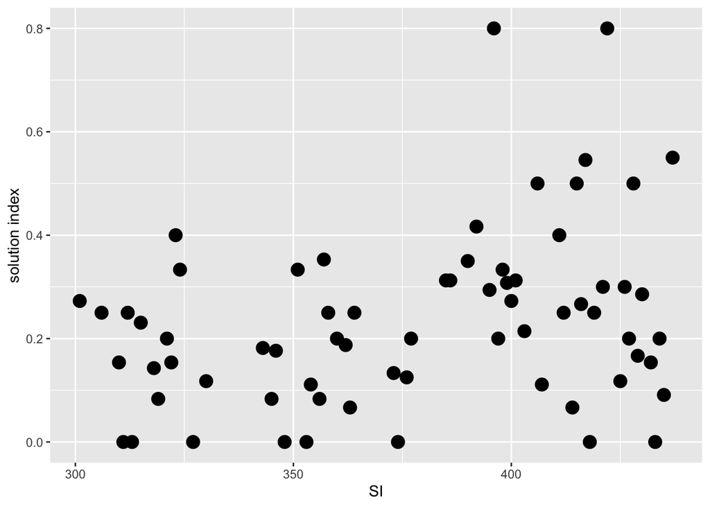

```r
 ggplot(DSP_DSI_DF, aes(x=subject_id,y=dsp_si_true_pct)) +
 geom_point(size=4, color = "black") +    labs(x ="SI", y = "solution index") + scale_fill_manual(values = c("#E2929D","#502E23"))
```

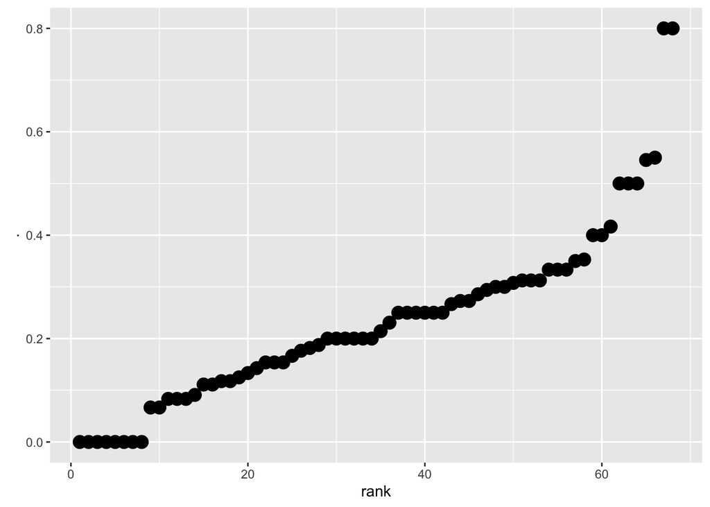

```r
 test <- DSP_DSI_DF$dsp_si_true_pct %>% sort() %>% as.data.frame() %>% mutate(rank=1:68)
 ggplot(test, aes(x=rank,y=.)) + geom_point(size=4, color = "black")
```

The table below summarizes all of the columns. Each row indicates a column location.

```r
TableOutput(describe(DSP_DSI_DF))
```

| vars | n | mean | sd | median | trimmed | mad | min | max | range | skew | kurtosis | se |
| --- | --- | --- | --- | --- | --- | --- | --- | --- | --- | --- | --- | --- |
| 1 | 68 | 377.4705882 | 41.7181268 | 385.5000000 | 378.8214286 | 48.9258000 | 301.0000000 | 437.0000000 | 136.0000000 | -0.2680440 | -1.3132822 | 5.0590660 |
| 2 | 68 | 125.6176471 | 6.4646673 | 128.0000000 | 126.5535714 | 4.4478000 | 95.0000000 | 132.0000000 | 37.0000000 | -2.0331559 | 5.8994634 | 0.7839561 |
| 3 | 68 | 17.0294118 | 1.8444802 | 16.0000000 | 17.0357143 | 2.9652000 | 14.0000000 | 20.0000000 | 6.0000000 | 0.0700381 | -0.8866767 | 0.2236761 |
| 4 | 68 | 4.7352941 | 0.8744746 | 5.0000000 | 4.9642857 | 0.0000000 | 1.0000000 | 6.0000000 | 5.0000000 | -3.0359306 | 8.9692433 | 0.1060456 |
| 5 | 68 | 34.2205882 | 19.4244388 | 34.5000000 | 34.2678571 | 24.4629000 | 1.0000000 | 67.0000000 | 66.0000000 | -0.0267971 | -1.2522736 | 2.3555592 |
| 6 | 68 | 1.0000000 | 0.0000000 | 1.0000000 | 1.0000000 | 0.0000000 | 1.0000000 | 1.0000000 | 0.0000000 | NaN | NaN | 0.0000000 |
| 7 | 68 | 1.0000000 | 0.0000000 | 1.0000000 | 1.0000000 | 0.0000000 | 1.0000000 | 1.0000000 | 0.0000000 | NaN | NaN | 0.0000000 |
| 8 | 68 | 1.3382353 | 0.4766266 | 1.0000000 | 1.3035714 | 0.0000000 | 1.0000000 | 2.0000000 | 1.0000000 | 0.6688078 | -1.5752154 | 0.0577995 |
| 9 | 68 | 1.0000000 | 0.0000000 | 1.0000000 | 1.0000000 | 0.0000000 | 1.0000000 | 1.0000000 | 0.0000000 | NaN | NaN | 0.0000000 |
| 10 | 68 | 50.2794118 | 3.6522150 | 50.0000000 | 50.1607143 | 4.4478000 | 43.0000000 | 60.0000000 | 17.0000000 | 0.3659869 | -0.0809019 | 0.4428961 |
| 11 | 68 | 50.3676471 | 3.7452633 | 50.0000000 | 50.1964286 | 4.4478000 | 44.0000000 | 61.0000000 | 17.0000000 | 0.5405568 | 0.2501914 | 0.4541799 |
| 12 | 68 | 2.3823529 | 1.2097787 | 2.0000000 | 2.3571429 | 1.4826000 | 1.0000000 | 4.0000000 | 3.0000000 | 0.1471737 | -1.5621581 | 0.1467072 |
| 13 | 68 | 1.8823529 | 0.9546338 | 1.0000000 | 1.8571429 | 0.0000000 | 1.0000000 | 3.0000000 | 2.0000000 | 0.2309191 | -1.8783530 | 0.1157664 |
| 14 | 25 | 0.7031561 | 0.2714834 | 0.6323248 | 0.6818066 | 0.2023856 | 0.3529723 | 1.3980198 | 1.0450475 | 0.7750245 | -0.2818126 | 0.0542967 |
| 15 | 27 | 1.6373602 | 0.7553523 | 1.5180956 | 1.5658374 | 0.7964491 | 0.7249980 | 3.3575483 | 2.6325504 | 0.8115706 | -0.3626700 | 0.1453676 |
| 16 | 24 | 2.9284296 | 0.9133302 | 2.8159437 | 2.8560514 | 0.7985749 | 1.7463817 | 5.3296238 | 3.5832421 | 0.7677153 | -0.0815971 | 0.1864328 |
| 17 | 27 | 1.7014009 | 0.6114097 | 1.5570508 | 1.6563504 | 0.5846475 | 0.7152435 | 3.2152239 | 2.4999804 | 0.7745251 | -0.2173477 | 0.1176659 |
| 18 | 25 | 347.5431023 | 43.6930913 | 350.3592141 | 348.2982800 | 42.9135113 | 257.0545313 | 425.0970950 | 168.0425637 | -0.0612139 | -0.5862858 | 8.7386183 |
| 19 | 27 | 366.1894602 | 61.0550694 | 349.5035229 | 361.9453125 | 41.1942757 | 265.3444172 | 518.0729118 | 252.7284946 | 0.8780122 | 0.4496107 | 11.7500536 |
| 20 | 24 | 366.1390247 | 82.8941567 | 346.6512816 | 357.6146624 | 58.4058901 | 252.0855158 | 558.1561749 | 306.0706591 | 0.9962613 | 0.0092618 | 16.9206989 |
| 21 | 27 | 359.6304015 | 54.6338066 | 346.4083052 | 357.0043026 | 44.2431928 | 258.1614881 | 488.3051734 | 230.1436853 | 0.6071732 | -0.0284128 | 10.5142810 |
| 22 | 25 | 46.5476478 | 23.4057351 | 42.2740347 | 44.0165334 | 22.8411978 | 19.1913707 | 103.1416095 | 83.9502388 | 0.8617352 | -0.2205715 | 4.6811470 |
| 23 | 27 | 54.1761701 | 30.6019173 | 51.1347251 | 50.9393520 | 27.7770929 | 20.9455022 | 128.1522211 | 107.2067189 | 1.0332192 | 0.0273054 | 5.8893417 |
| 24 | 24 | 66.0825849 | 25.4285866 | 60.0950231 | 63.8088979 | 24.4631084 | 35.1538947 | 135.7723902 | 100.6184955 | 0.8480505 | 0.0982169 | 5.1905885 |
| 25 | 27 | 54.2211579 | 24.1358174 | 46.5455619 | 51.7084993 | 15.4094723 | 27.9082729 | 109.6747831 | 81.7665102 | 1.0454908 | -0.0716324 | 4.6449402 |
| 26 | 68 | 1.8529412 | 0.3567978 | 2.0000000 | 1.9285714 | 0.0000000 | 1.0000000 | 2.0000000 | 1.0000000 | -1.9492883 | 1.8272417 | 0.0432681 |
| 27 | 58 | 0.1544494 | 0.1860061 | 0.1250000 | 0.1232597 | 0.0926625 | 0.0000000 | 1.0000000 | 1.0000000 | 3.2254943 | 11.8923449 | 0.0244238 |
| 28 | 58 | 267.1206897 | 34.7850934 | 270.5000000 | 269.1666667 | 28.9107000 | 185.0000000 | 345.0000000 | 160.0000000 | -0.5542103 | -0.0965885 | 4.5675065 |
| 29 | 58 | 1.0980122 | 0.1566073 | 1.0769650 | 1.0876153 | 0.1720838 | 0.8362463 | 1.4906232 | 0.6543769 | 0.6214228 | -0.1029839 | 0.0205635 |
| 30 | 58 | 0.1003211 | 2.1094656 | 0.1989727 | 0.1833200 | 2.0987647 | -5.0139610 | 4.5297635 | 9.5437245 | -0.4046822 | -0.2603749 | 0.2769864 |

[output cut: 56 more lines]

### So can we then try and normalize the data?

Here let’s normalize using log transform. Log transform does change the skew but also some numbers (0) are now labeled as inf. Meaning we should do something to make those turn into an acutal number perhaps 0.0001?

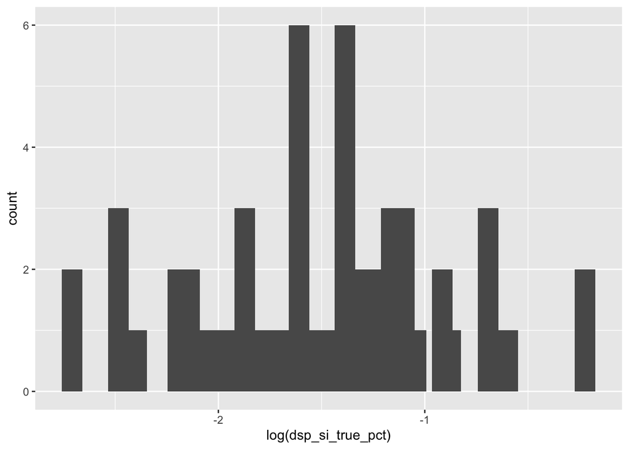

```r
ggplot(DSP_DSI_DF, aes(x=log(dsp_si_true_pct))) +
   geom_bar(width = 0.1)
```

```r
#I think things need to be changed from 0 to 0. 001
shapiro.test(log(DSP_DSI_DF$dsp_si_true_pct)) # this comes out as Na but shuyings did not so idk why that's happening.
```

```
##
##  Shapiro-Wilk normality test
##
## data:  log(DSP_DSI_DF$dsp_si_true_pct)
## W = NaN, p-value = NA
```

LEt’s try a square root transform

The square root transform normalizes it a bit more but it still failed normality test.

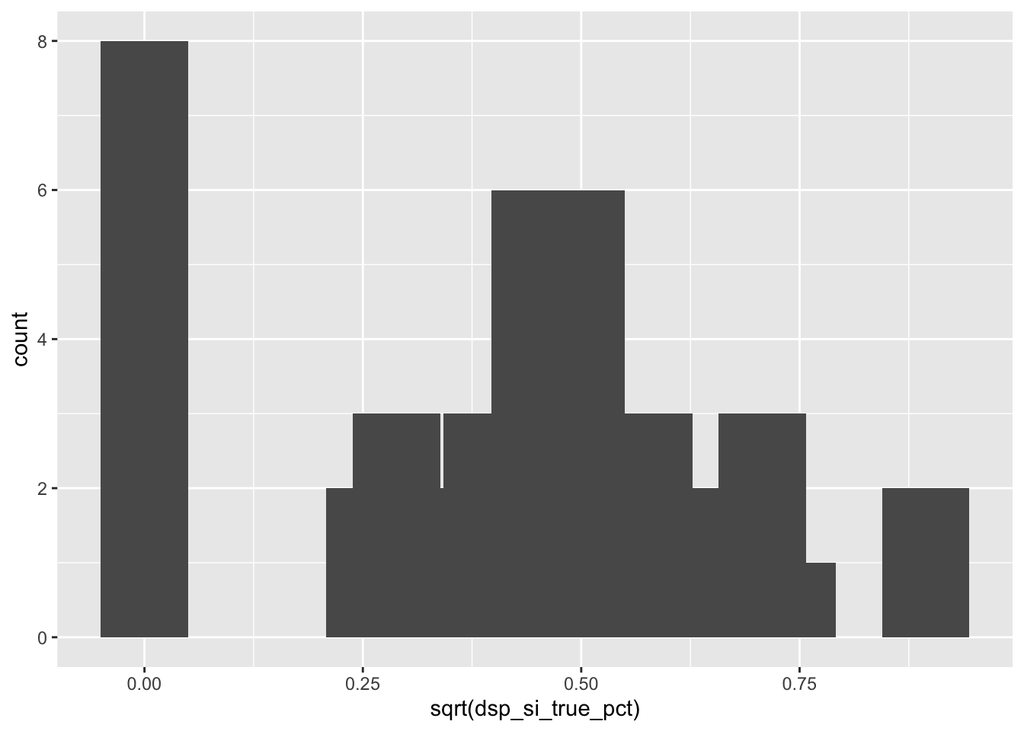

```r
ggplot(DSP_DSI_DF, aes(x=sqrt(dsp_si_true_pct))) +
   geom_bar(width = 0.1)
```

```r
shapiro.test(sqrt(DSP_DSI_DF$dsp_si_true_pct)) #
```

```
##
##  Shapiro-Wilk normality test
##
## data:  sqrt(DSP_DSI_DF$dsp_si_true_pct)
## W = 0.92755, p-value = 0.0006999
```

#### Females DSP Distribution & normality (behav only)

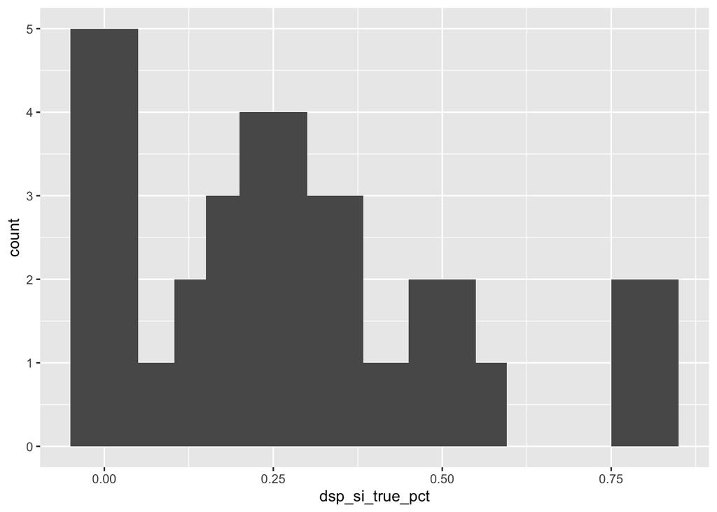

```r
ggplot(f_data_dsp, aes(x=dsp_si_true_pct)) +
   geom_bar(width = 0.1)
```

```r
shapiro.test(f_data_dsp$dsp_si_true_pct)
```

```
##
##  Shapiro-Wilk normality test
##
## data:  f_data_dsp$dsp_si_true_pct
## W = 0.90632, p-value = 0.0015
```

```r
df_dsp_norm <- f_data_dsp %>%
  mutate_at(scale, .vars = vars(estradiol_spatial_pg_ml,
                                fsh_spatial_miu_ml,
                                dsp_si_true_pct))
```

LEt’s look at a transformation of all womens data

log transform: again NA for normality test but does appear to fix it a bit

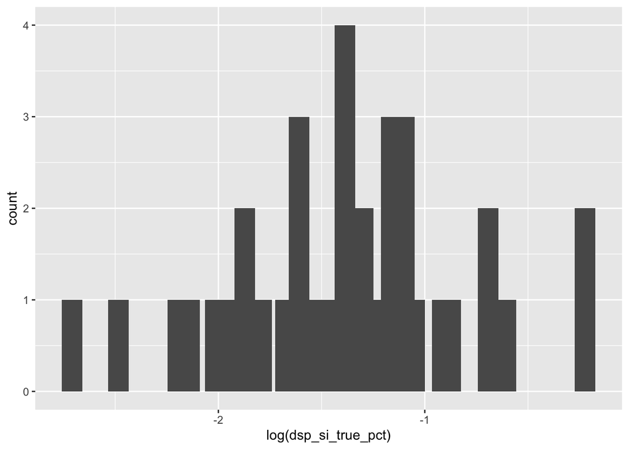

```r
ggplot(f_data_dsp, aes(x=log(dsp_si_true_pct))) +
   geom_bar(width = 0.1)
```

```r
#I think things need to be changed from 0 to 0. 001
shapiro.test(log(f_data_dsp$dsp_si_true_pct)) # this comes out as Na but shuyings did not so idk why that's happening.
```

```
##
##  Shapiro-Wilk normality test
##
## data:  log(f_data_dsp$dsp_si_true_pct)
## W = NaN, p-value = NA
```

Square Transform: again still skewefd and fails normality.

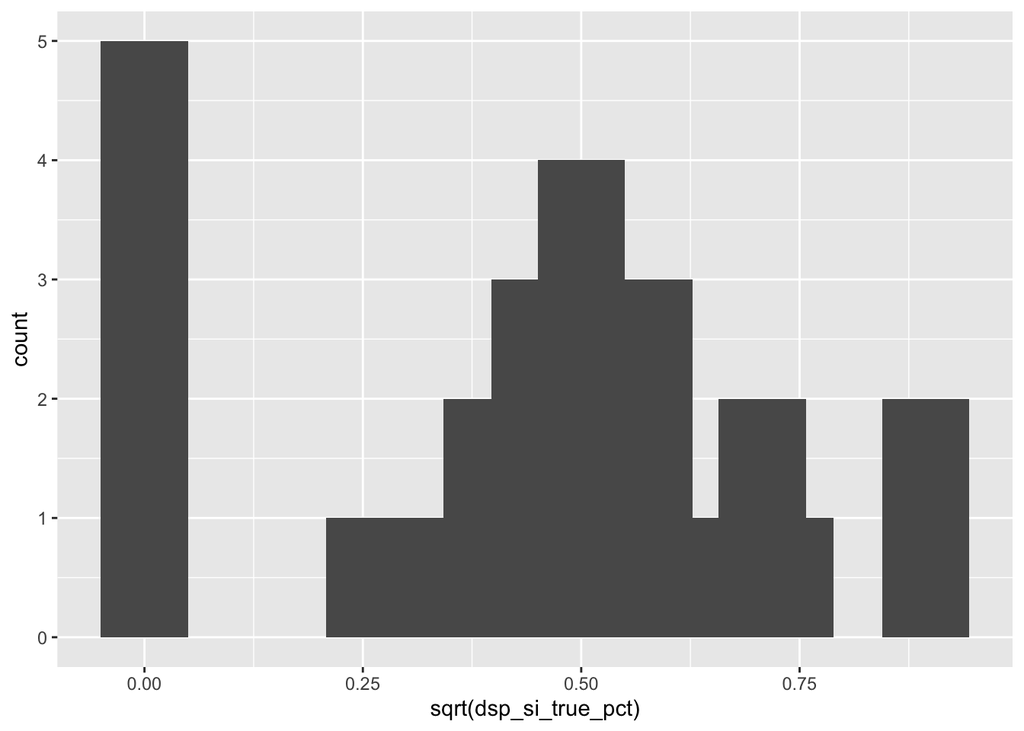

```r
ggplot(f_data_dsp, aes(x=sqrt(dsp_si_true_pct))) +
   geom_bar(width = 0.1)
```

```r
shapiro.test(sqrt(f_data_dsp$dsp_si_true_pct)) #
```

```
##
##  Shapiro-Wilk normality test
##
## data:  sqrt(f_data_dsp$dsp_si_true_pct)
## W = 0.90467, p-value = 0.001328
```

#### Males DSP Distribution & normality (behav only)

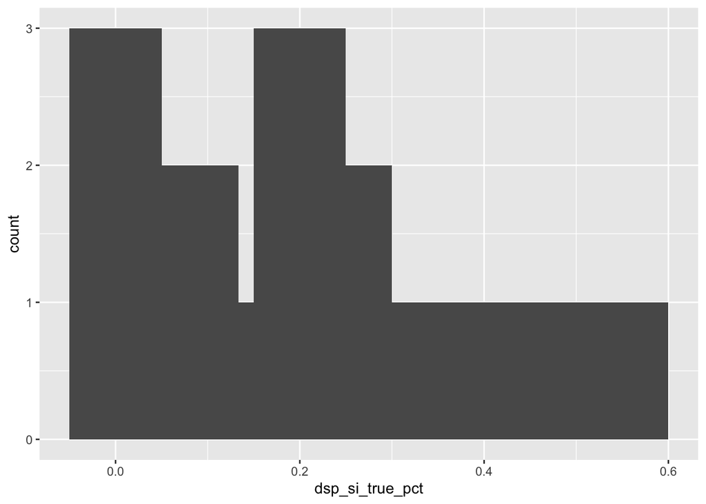

```r
ggplot(m_data_dsp, aes(x=dsp_si_true_pct)) +
   geom_bar(width = 0.1)
```

```r
shapiro.test(m_data_dsp$dsp_si_true_pct)
```

```
##
##  Shapiro-Wilk normality test
##
## data:  m_data_dsp$dsp_si_true_pct
## W = 0.91952, p-value = 0.06505
```

#### Estradiol distribution & normality

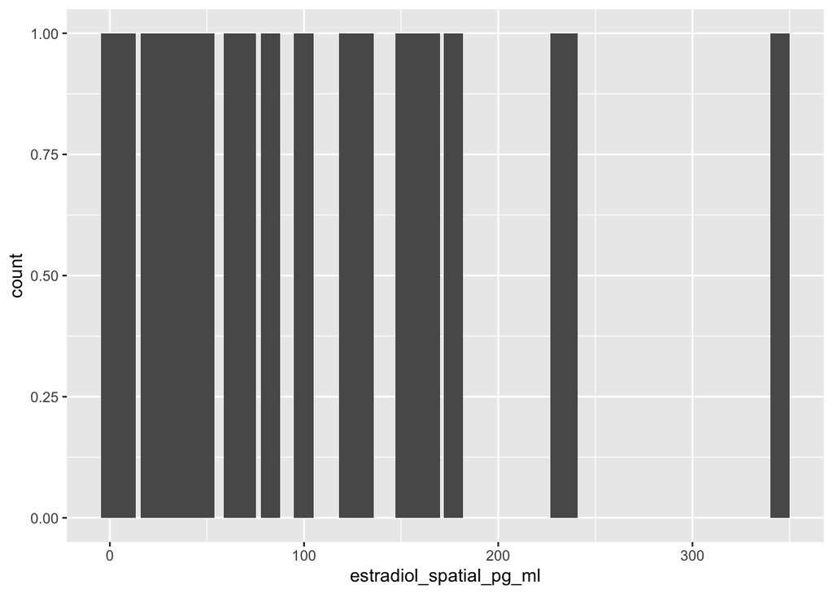

```r
ggplot(f_data_dsp, aes(x=estradiol_spatial_pg_ml)) +
   geom_bar(width = 10)
```

```r
shapiro.test(f_data_dsp$estradiol_spatial_pg_ml)
```

```
##
##  Shapiro-Wilk normality test
##
## data:  f_data_dsp$estradiol_spatial_pg_ml
## W = 0.77536, p-value = 7.126e-07
```

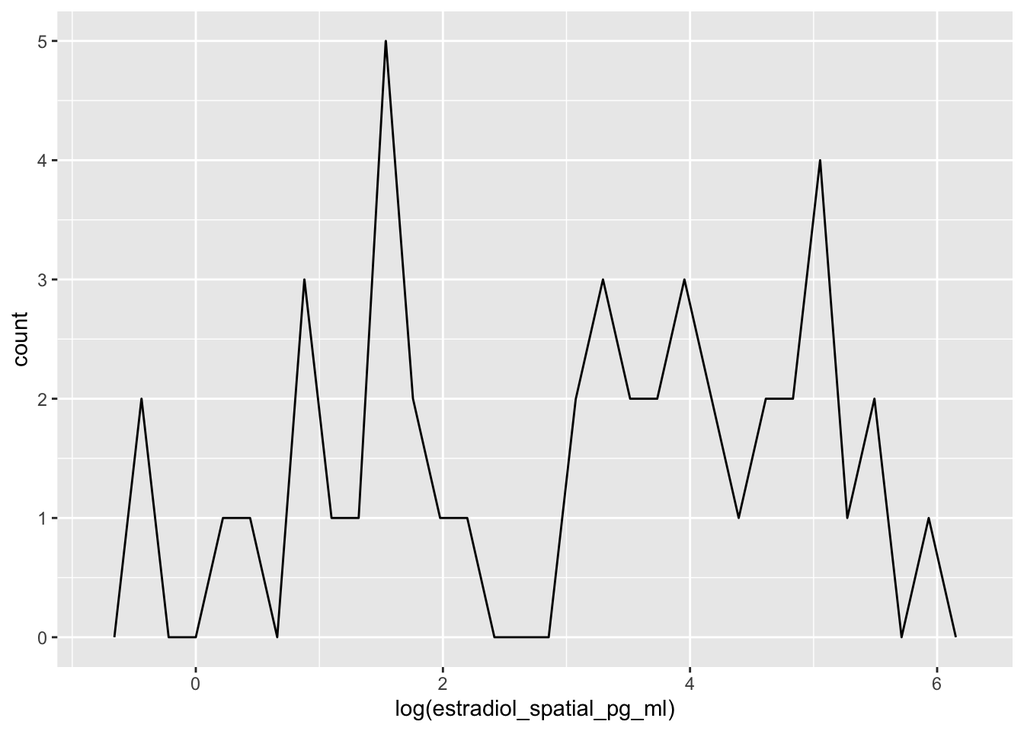

```r
ggplot(f_data_dsp, aes(x=log(estradiol_spatial_pg_ml))) +
   geom_freqpoly(width = 10)
```

```r
shapiro.test(log(f_data_dsp$estradiol_spatial_pg_ml))
```

```
##
##  Shapiro-Wilk normality test
##
## data:  log(f_data_dsp$estradiol_spatial_pg_ml)
## W = 0.94482, p-value = 0.03244
```

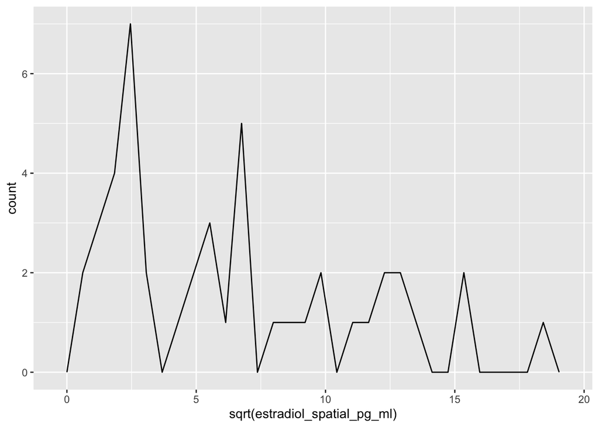

```r
ggplot(f_data_dsp, aes(x=sqrt(estradiol_spatial_pg_ml))) +
   geom_freqpoly(width = 10)
```

```r
shapiro.test(sqrt(f_data_dsp$estradiol_spatial_pg_ml))
```

```
##
##  Shapiro-Wilk normality test
##
## data:  sqrt(f_data_dsp$estradiol_spatial_pg_ml)
## W = 0.90713, p-value = 0.001592
```

### FSH distribution & normality

[figure not shown]

```r
ggplot(f_data_dsp, aes(x=fsh_spatial_miu_ml)) +
   geom_bar(width = 10)
```

```r
shapiro.test(f_data_dsp$fsh_spatial_miu_ml)
```

```
##
##  Shapiro-Wilk normality test
##
## data:  f_data_dsp$fsh_spatial_miu_ml
## W = 0.90614, p-value = 0.00148
```

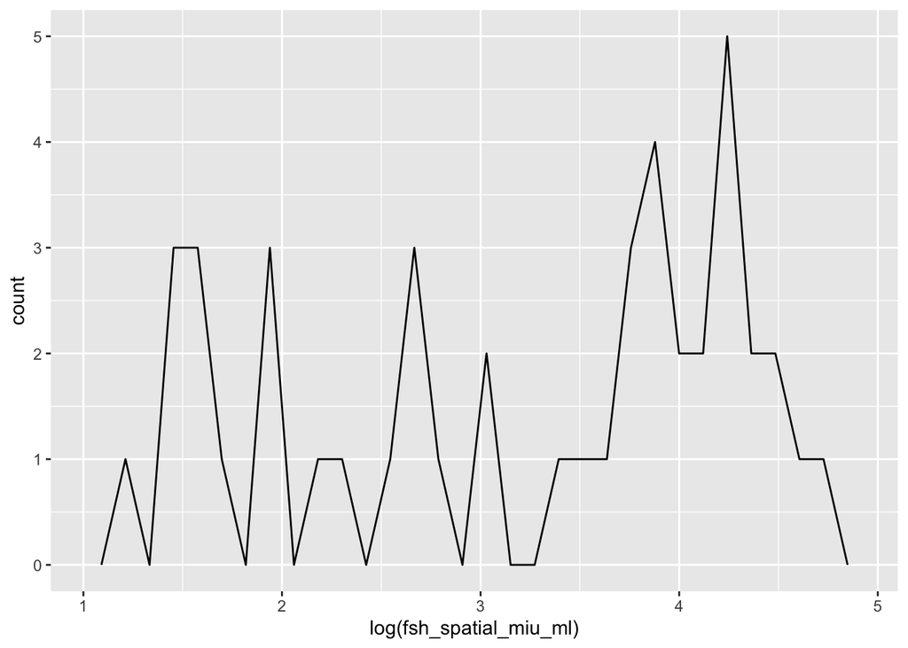

```r
ggplot(f_data_dsp, aes(x=log(fsh_spatial_miu_ml))) +
   geom_freqpoly(width = 10)
```

```r
shapiro.test(log(f_data_dsp$fsh_spatial_miu_ml))
```

```
##
##  Shapiro-Wilk normality test
##
## data:  log(f_data_dsp$fsh_spatial_miu_ml)
## W = 0.90094, p-value = 0.001014
```

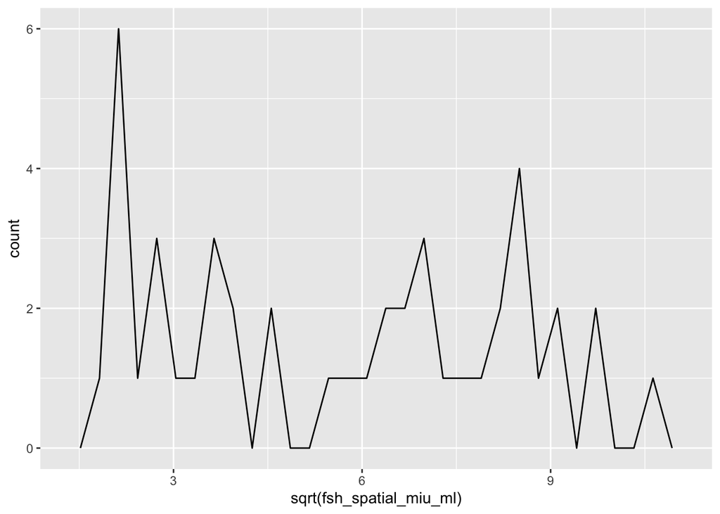

```r
ggplot(f_data_dsp, aes(x=sqrt(fsh_spatial_miu_ml))) +
   geom_freqpoly(width = 10)
```

```r
shapiro.test(sqrt(f_data_dsp$fsh_spatial_miu_ml))
```

```
##
##  Shapiro-Wilk normality test
##
## data:  sqrt(f_data_dsp$fsh_spatial_miu_ml)
## W = 0.92245, p-value = 0.005125
```

No good way to normalize this data so far. I will probably leave it as is.

### TRactometry results DF

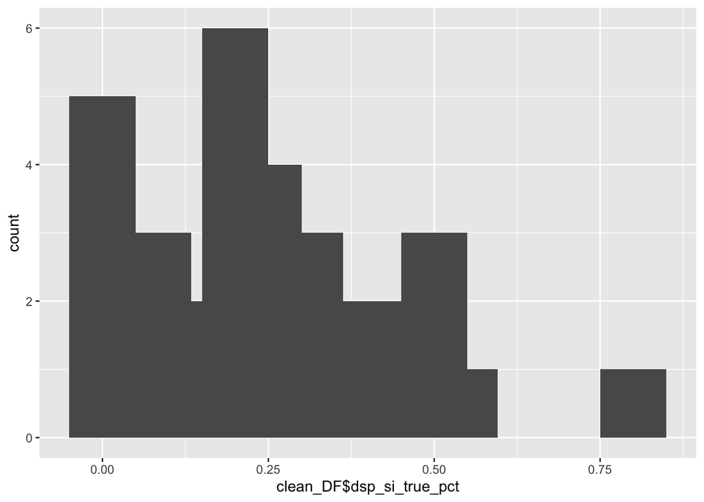

```r
ggplot(clean_DF, aes(x=clean_DF$dsp_si_true_pct)) +
   geom_bar(width = 0.1)
```

```r
shapiro.test(clean_DF$dsp_si_true_pct)
```

```
##
##  Shapiro-Wilk normality test
##
## data:  clean_DF$dsp_si_true_pct
## W = 0.94164, p-value = 0.01194
```

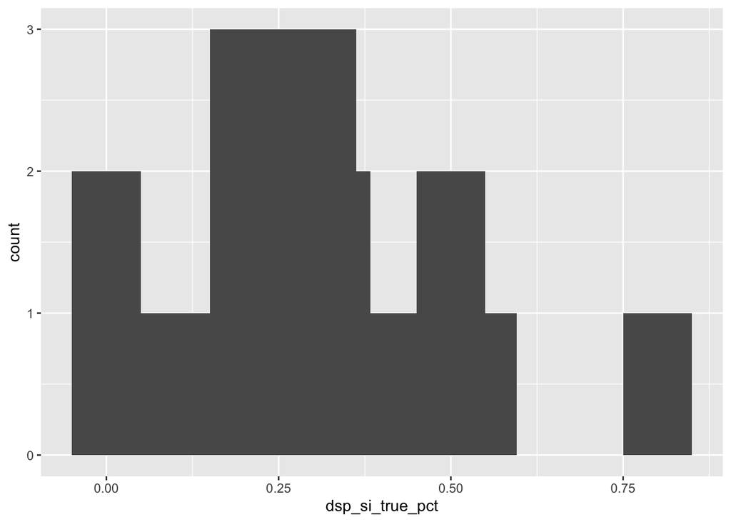

```r
ggplot(all_women_clean_df, aes(x=dsp_si_true_pct)) +
   geom_bar(width = 0.1)
```

```r
shapiro.test(all_women_clean_df$dsp_si_true_pct)
```

```
##
##  Shapiro-Wilk normality test
##
## data:  all_women_clean_df$dsp_si_true_pct
## W = 0.9354, p-value = 0.04998
```

So let’s try transforming this

Log transform all subjects. This visually looks much less skewed but also has some infinate numbers so we can check normality. Might need to change the inf to 0?

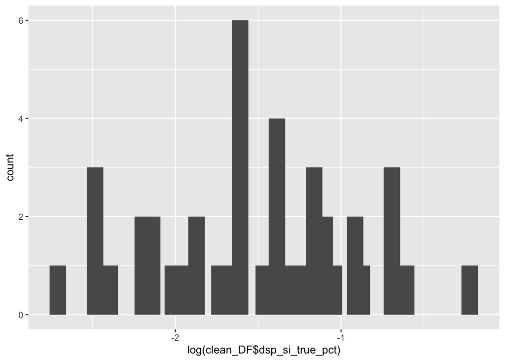

```r
ggplot(clean_DF, aes(x=log(clean_DF$dsp_si_true_pct))) +
   geom_bar(width = 0.1)
```

```r
shapiro.test(log(clean_DF$dsp_si_true_pct))
```

```
##
##  Shapiro-Wilk normality test
##
## data:  log(clean_DF$dsp_si_true_pct)
## W = NaN, p-value = NA
```

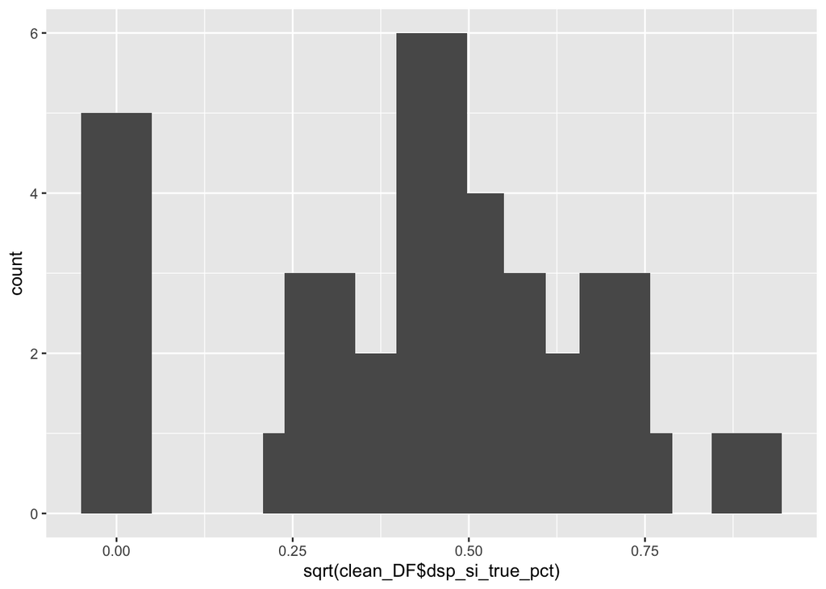

```r
ggplot(clean_DF, aes(x=sqrt(clean_DF$dsp_si_true_pct))) +
   geom_bar(width = 0.1)
```

```r
shapiro.test(sqrt(clean_DF$dsp_si_true_pct))
```

```
##
##  Shapiro-Wilk normality test
##
## data:  sqrt(clean_DF$dsp_si_true_pct)
## W = 0.93064, p-value = 0.004288
```

LEt’s look at the females

Log transform all subjects. This visually looks much less skewed but also has some infinate numbers so we can check normality. Might need to change the inf to 0?

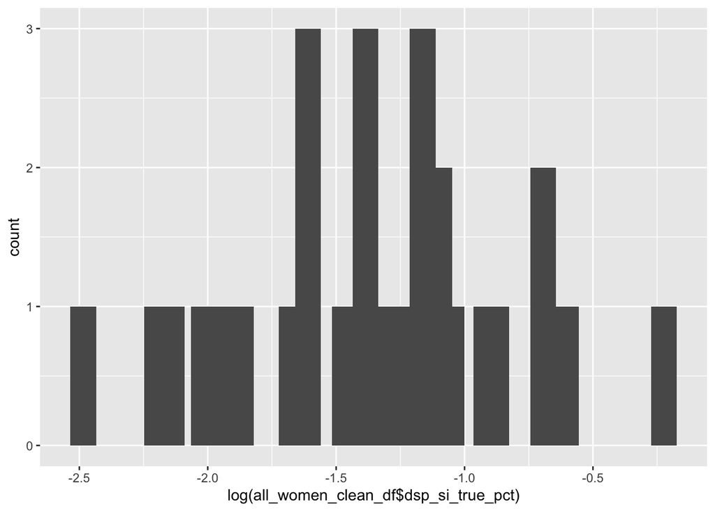

```r
ggplot(all_women_clean_df, aes(x=log(all_women_clean_df$dsp_si_true_pct))) +
   geom_bar(width = 0.1)
```

```r
shapiro.test(log(all_women_clean_df$dsp_si_true_pct))
```

```
##
##  Shapiro-Wilk normality test
##
## data:  log(all_women_clean_df$dsp_si_true_pct)
## W = NaN, p-value = NA
```

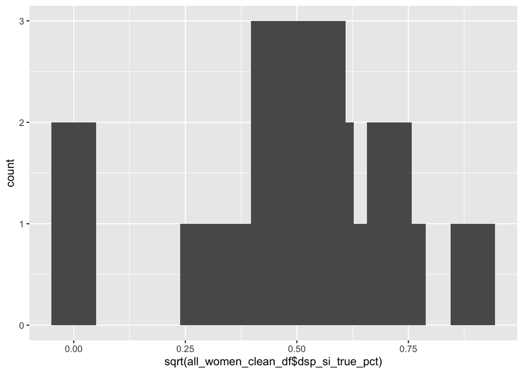

```r
ggplot(all_women_clean_df, aes(x=sqrt(all_women_clean_df$dsp_si_true_pct))) +
   geom_bar(width = 0.1)
```

```r
shapiro.test(sqrt(all_women_clean_df$dsp_si_true_pct))
```

```
##
##  Shapiro-Wilk normality test
##
## data:  sqrt(all_women_clean_df$dsp_si_true_pct)
## W = 0.91911, p-value = 0.01731
```

## Step 2: Prepare the mediation by grabbing our final df. Removing any rows that are NA

```r
mediation_estradiol_DF <-
  clean_DF %>% dplyr::select(
    subject_id,
    sex,
    age_spatial_years,
    repo_status,
    dsp_si_true_pct,
    estradiol_scan_pg_ml,
    estradiol_spatial_pg_ml,
    progesterone_scan_ng_ml,
    testosterone_scan_ng_dl,
    fsh_scan_miu_ml,
    QA_L_fornix,
    QA_R_fornix,
    MD_L_fornix,
    MD_R_fornix,
    MD_Whole_Fornix,
    QA_Whole_Fornix
  ) %>% filter(!is.na(dsp_si_true_pct)) %>% filter(!is.na(estradiol_spatial_pg_ml)) %>% filter(sex == "Female")
```

```r
mediation_test_DF <-
  clean_DF %>% dplyr::select(
    subject_id,
    sex,
    age_spatial_years,
    repo_status,
    dsp_si_true_pct,
    estradiol_scan_pg_ml,
    progesterone_scan_ng_ml,
    testosterone_scan_ng_dl,
    fsh_scan_miu_ml,
    QA_L_fornix,
    QA_R_fornix,
    MD_L_fornix,
    MD_R_fornix
  ) %>% filter(!is.na(dsp_si_true_pct)) %>% filter(!is.na(testosterone_scan_ng_dl)) %>% filter(sex == "Female")
```

```r
mediation_FSH_DF <-
  clean_DF %>% dplyr::select(
    subject_id,
    sex,
    age_spatial_years,
    repo_status,
    dsp_si_true_pct,
    estradiol_scan_pg_ml,
    progesterone_scan_ng_ml,
    testosterone_scan_ng_dl,
    fsh_scan_miu_ml,
    fsh_spatial_miu_ml,
    QA_L_fornix,
    QA_R_fornix,
    MD_L_fornix,
    MD_R_fornix,
    MD_Whole_Fornix,
    QA_Whole_Fornix
  ) %>% filter(!is.na(dsp_si_true_pct)) %>% filter(!is.na(fsh_scan_miu_ml)) %>% filter(sex == "Female")
```

# Step 3: Can we replicate shuyings findings?

## Estradiol

Below is the code that recreates shuyings results in her dissertation. “For the DSP task, women with higher estradiol levels took more shortcuts, such that higher estradiol levels were positively associated with solution index (rs(45) = 0.42, p = 0.002)”. She used a one-tail spearman correlation because dsp and estradiol fail normality tests. Additionally she removed two subjects due to outliars.

### Estradiol and Solution Index

I reran these but with my final subset of people because i was able to replicate shuyings findings with her dataset.

**One-tailed correlation using all females**

- Here he have code for both spatial and scan. I’m going to comment the scan ones and just use spatial. Results are as follows: **Estradiol is positively correlated with SI (n=47, r(45)=0.42, p=value=0.002).** This is what shuying originally found.

```r
# this one uses spatial hormones
cor.test(Behavioronly_Female_data_dsp$estradiol_spatial_pg_ml,
         Behavioronly_Female_data_dsp$dsp_si_true_pct,
         conf.level = 0.95,
         alternative = "greater",
         method = "spearman")
```

```
##
##  Spearman's rank correlation rho
##
## data:  Behavioronly_Female_data_dsp$estradiol_spatial_pg_ml and Behavioronly_Female_data_dsp$dsp_si_true_pct
## S = 10012, p-value = 0.001601
## alternative hypothesis: true rho is greater than 0
## sample estimates:
##     rho
## 0.42112
```

```r
# #This one uses scan hormones
# cor.test(Behavioronly_Female_data_dsp$estradiol_scan_pg_ml,
#          Behavioronly_Female_data_dsp$dsp_si_true_pct,
#          conf.level = 0.95,
#          alternative = "greater",
#          method = "spearman")
```

**removing outliar** Here it is if we remove outliars p= 0.0035. REplicates shuyings code and results. probably not adding this tho. so

```r
f_beh_data_outlier_e <- Behavioronly_Female_data_dsp  %>%  filter(!subject_id %in% c("415", "355"))

cor.test(f_beh_data_outlier_e$estradiol_spatial_pg_ml,
         f_beh_data_outlier_e$dsp_si_true_pct,
         alternative = "greater",
         conf.level = 0.95,
         method = "spearman")
```

```
##
##  Spearman's rank correlation rho
##
## data:  f_beh_data_outlier_e$estradiol_spatial_pg_ml and f_beh_data_outlier_e$dsp_si_true_pct
## S = 9859.2, p-value = 0.003529
## alternative hypothesis: true rho is greater than 0
## sample estimates:
##      rho
## 0.391972
```

**One-tailed correlation controlling for AGE using all females**

Here we want to control for age. I saw shuying use two different approaches. Here is the first one she used. it allows for a one-railed hypothesis. **Estradiol is significantly associated with SI when controlling for age (n=47, r(45)=0.28, p=0.029).** This replicated Shuyings results

```r
x <- Behavioronly_Female_data_dsp$estradiol_spatial_pg_ml
y <- Behavioronly_Female_data_dsp$dsp_si_true_pct
z <- Behavioronly_Female_data_dsp$age_spatial_years
cor.test(lm(x ~ z)$residuals,
         lm(y ~ z)$residuals,
         alternative = "greater",
         conf.level = 0.95,
         method = "spearman")
```

```
##
##  Spearman's rank correlation rho
##
## data:  lm(x ~ z)$residuals and lm(y ~ z)$residuals
## S = 12461, p-value = 0.02852
## alternative hypothesis: true rho is greater than 0
## sample estimates:
##       rho
## 0.2795525
```

**Two-tailed correlation controlling for AGE using all females** This is not what we want but i’m leaving it in here in case i forget that i already did this.

```r
pcor.test(Behavioronly_Female_data_dsp$estradiol_spatial_pg_ml,
          Behavioronly_Female_data_dsp$dsp_si_true_pct,
          Behavioronly_Female_data_dsp$age_spatial_years,
          method = "spearman") #p-value=0.02876795
```

```
##    estimate    p.value statistic  n gp   Method
## 1 0.3226078 0.02876795  2.260818 47  1 spearman
```

**One-tailed correlation using excluding 2 females missing DSI scan** - This is excluding two women who do not have scans. originally did this but we wanted to try and get as many Ns as possible so manuscript will include those 2. See code and results above.

- Here we have code for both spatial and scan. I’m going to comment the scan ones and just use spatial. Results are as follows: **Estradiol is positively correlated with SI (n=45, r(43)=0.46, p=value=0.0008).**

```r
# this one uses spatial hormones
cor.test(f_data_dsp$estradiol_spatial_pg_ml,
         f_data_dsp$dsp_si_true_pct,
         conf.level = 0.95,
         alternative = "greater",
         method = "spearman")
```

```
##
##  Spearman's rank correlation rho
##
## data:  f_data_dsp$estradiol_spatial_pg_ml and f_data_dsp$dsp_si_true_pct
## S = 8235.5, p-value = 0.00079
## alternative hypothesis: true rho is greater than 0
## sample estimates:
##       rho
## 0.4574789
```

```r
# #This one uses scan hormones
# cor.test(f_data_dsp$estradiol_scan_pg_ml,
#          f_data_dsp$dsp_si_true_pct,
#          conf.level = 0.95,
#          alternative = "greater",
#          method = "spearman")
```

**One-tailed correlation using excluding 2 females missing DSI scan controlling for AGE**

Here we want to control for age. I saw shuying use two different approaches. Here is the first one she used. it allows for a one-railed hypothesis. **Estradiol is significantly associated with SI when controlling for age (n=45, r(43)=0.32, p=0.02).**

```r
x <- f_data_dsp$estradiol_spatial_pg_ml
y <- f_data_dsp$dsp_si_true_pct
z <- f_data_dsp$age_spatial_years
cor.test(lm(x ~ z)$residuals,
         lm(y ~ z)$residuals,
         alternative = "greater",
         conf.level = 0.95,
         method = "spearman")
```

```
##
##  Spearman's rank correlation rho
##
## data:  lm(x ~ z)$residuals and lm(y ~ z)$residuals
## S = 10370, p-value = 0.01697
## alternative hypothesis: true rho is greater than 0
## sample estimates:
##       rho
## 0.3168747
```

**two-tailed correlation using excluding 2 females missing DSI scan controlling for AGE** Here is a two tailed version but this is wrong.

```r
pcor.test(f_data_dsp$estradiol_spatial_pg_ml,
          f_data_dsp$dsp_si_true_pct,
          f_data_dsp$age_spatial_years,
          method = "spearman") #p-value=0.02876795
```

```
##   estimate    p.value statistic  n gp   Method
## 1 0.369274 0.01363063  2.575182 45  1 spearman
```

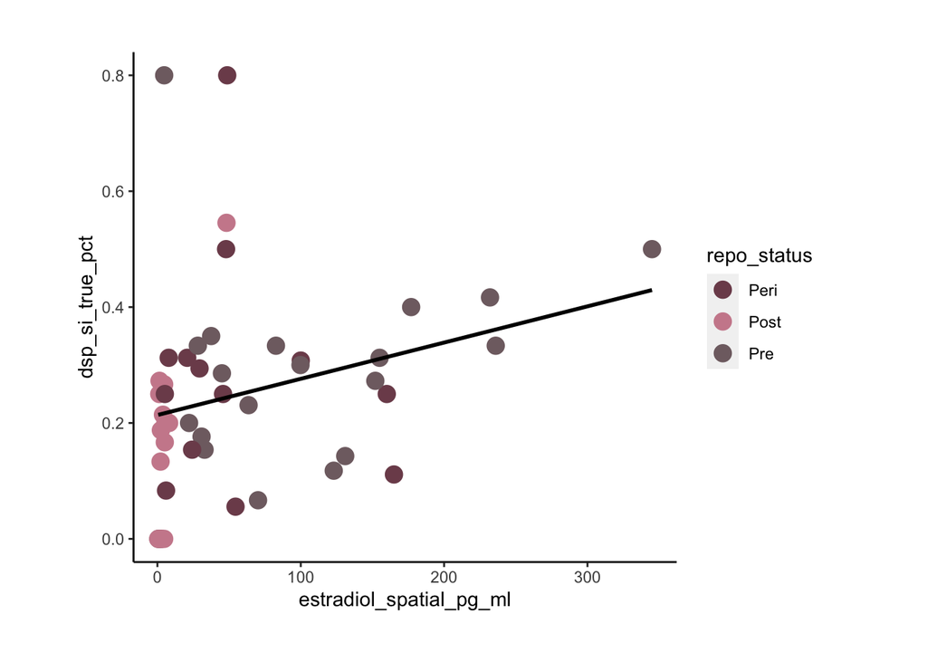

```r
# Using
#PDF 9 X 6
ggplot(data = Behavioronly_Female_data_dsp, aes(x = estradiol_spatial_pg_ml,
                               y = dsp_si_true_pct, color=repo_status)) +
  geom_point(aes(color = factor(repo_status)), size=4) +
  scale_color_manual(values=c("#7d4c5a", "#CD8A9B","#806d71")) +
   stat_smooth(method = "lm",
              formula = y ~ x,
              geom = "smooth",
             color="Black",
             se=FALSE)+
  theme(panel.background =element_blank(),
         axis.line = element_line(colour = "black"),
         plot.margin = margin(1, 2, 1, 1.5, "cm"),
         plot.title = element_text(hjust = 0.5, vjust = 2, size = 16, face="bold"))
```

## FSH

**One-tailed correlation using all females**

- Here he have code for both spatial and scan. I’m going to comment the scan ones and just use spatial. Results are as follows: **FSH is negatively correlated with SI (n=46, r(44)=-0.28, p=value=0.029).** This is what shuying originally found.

```r
# we need to make a new DF for FSH specifc people

FSH__Female_data_dsp <- Behavioronly_Female_data_dsp %>% filter(!is.na(fsh_spatial_miu_ml))

# this one uses spatial hormones
cor.test(FSH__Female_data_dsp$fsh_spatial_miu_ml,
         FSH__Female_data_dsp$dsp_si_true_pct,
         conf.level = 0.95,
         alternative = "less",
         method = "spearman")
```

```
##
##  Spearman's rank correlation rho
##
## data:  FSH__Female_data_dsp$fsh_spatial_miu_ml and FSH__Female_data_dsp$dsp_si_true_pct
## S = 20779, p-value = 0.02903
## alternative hypothesis: true rho is less than 0
## sample estimates:
##        rho
## -0.2814973
```

```r
# #This one uses scan hormones
# cor.test(Behavioronly_Female_data_dsp$fsh_spatial_miu_ml,
#          Behavioronly_Female_data_dsp$dsp_si_true_pct,
#          conf.level = 0.95,
#          alternative = "less",
#          method = "spearman")
```

**One-tailed correlation controlling for AGE using all females** Here we want to control for age. I saw shuying use two different approaches. Here is the first one she used. it allows for a one-railed hypothesis. **FSH is not significantly associated with SI when controlling for age (n=46, r(44)= -0.24, p=0.06).** This replicated Shuyings results

Below is the code that replicated shuyings script for controlling for age.P#0.05638. It’ a correlation with the residuals.

```r
x <- FSH__Female_data_dsp$fsh_spatial_miu_ml
y <- FSH__Female_data_dsp$dsp_si_true_pct
z <- FSH__Female_data_dsp$age_spatial_years
cor.test(lm(x ~ z)$residuals,
         lm(y ~ z)$residuals,
         alternative = "less",
         conf.level = 0.95,
         method = "spearman")
```

```
##
##  Spearman's rank correlation rho
##
## data:  lm(x ~ z)$residuals and lm(y ~ z)$residuals
## S = 20058, p-value = 0.05638
## alternative hypothesis: true rho is less than 0
## sample estimates:
##        rho
## -0.2370101
```

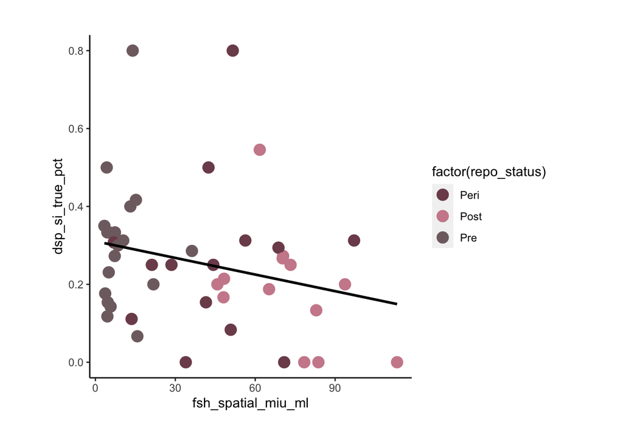

```r
ggplot(data = FSH__Female_data_dsp, aes(x = fsh_spatial_miu_ml,
                               y = dsp_si_true_pct)) +
  geom_point(aes(color = factor(repo_status)), size=4) +
  scale_color_manual(values=c("#7d4c5a", "#CD8A9B","#806d71")) +
 stat_smooth(method = "lm",
              formula = y ~ x,
              geom = "smooth",
             color="Black",
             se=FALSE) +
  theme(panel.background =element_blank(),
         axis.line = element_line(colour = "black"),
         plot.margin = margin(1, 2, 1, 1.5, "cm"),
         plot.title = element_text(hjust = 0.5, vjust = 2, size = 16, face="bold"))
```

## Hormone comparison

### estradiol

Average Scan Estradiol 67.2621212

Average Spatial Estradiol 69.2675758

```r
hormones_df <- all_women_clean_df %>% dplyr::select(c("subject_id","estradiol_scan_pg_ml","estradiol_spatial_pg_ml","progesterone_scan_ng_ml","progesterone_spatial_ng_ml","fsh_scan_miu_ml","fsh_spatial_miu_ml")) #Creating a df that contains just the hormones so i can visualize them side by side.
```

Density plots of the scan and spatial estradiol.

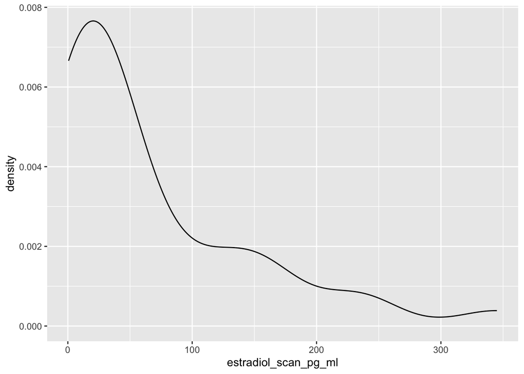

```r
ggplot(data=all_women_clean_df, aes(x=estradiol_scan_pg_ml)) +
  geom_density()
```

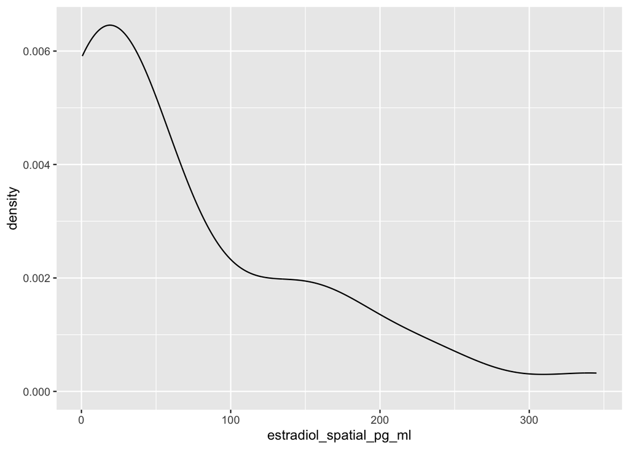

```r
ggplot(data=all_women_clean_df, aes(x=estradiol_spatial_pg_ml)) +
  geom_density()
```

### FSH

Average Scan FSH 39.5954545

Average Spatial FSH 39.5954545

Density plots of the scan and spatial FSH. They’re basically identical tho so i’ll need to check these.

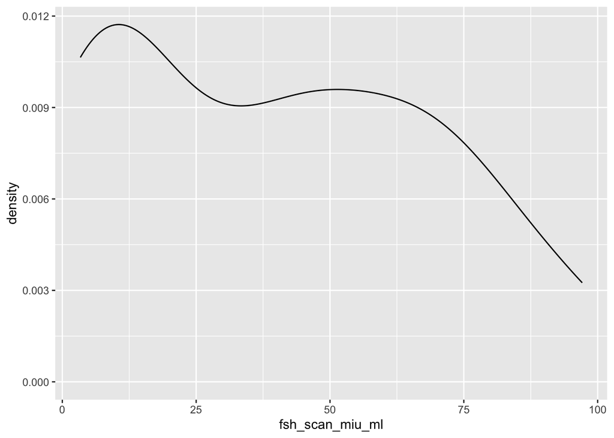

```r
ggplot(data=all_women_clean_df, aes(x=fsh_scan_miu_ml)) +
  geom_density()
```

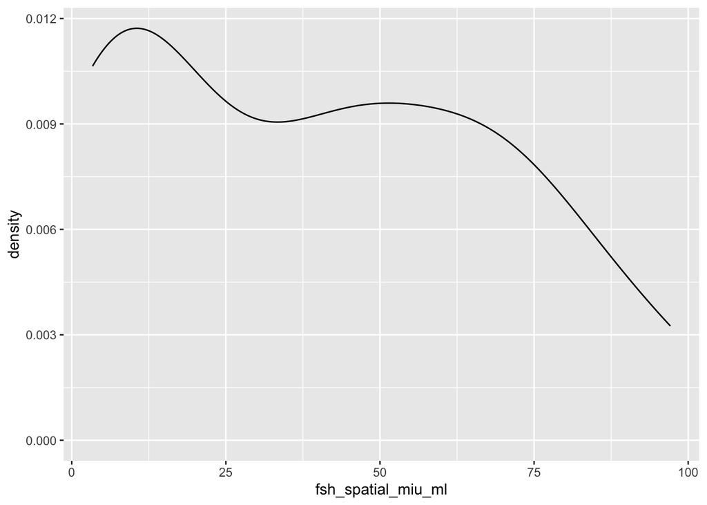

```r
ggplot(data=all_women_clean_df, aes(x=fsh_spatial_miu_ml)) +
  geom_density()
```

# Step 4: Mediation

## Estradiol

X <- White Matter Y <- DSP SI M <- Hormones /FSH

```r
model.1 <- lm(dsp_si_true_pct ~  MD_Whole_Fornix , mediation_estradiol_DF)
summary(model.1)
```

```
##
## Call:
## lm(formula = dsp_si_true_pct ~ MD_Whole_Fornix, data = mediation_estradiol_DF)
##
## Residuals:
##       Min        1Q    Median        3Q       Max
## -0.296260 -0.071286 -0.006164  0.060894  0.277026
##
## Coefficients:
##                 Estimate Std. Error t value Pr(>|t|)
## (Intercept)       0.4974     0.3487   1.426    0.168
## MD_Whole_Fornix  -0.4545     0.6669  -0.682    0.503
##
## Residual standard error: 0.1335 on 21 degrees of freedom
##   (10 observations deleted due to missingness)
## Multiple R-squared:  0.02164,    Adjusted R-squared:  -0.02494
## F-statistic: 0.4646 on 1 and 21 DF,  p-value: 0.5029
```

```r
model.1.Left <- lm(dsp_si_true_pct ~  MD_L_fornix , mediation_estradiol_DF)
summary(model.1.Left)
```

```
##
## Call:
## lm(formula = dsp_si_true_pct ~ MD_L_fornix, data = mediation_estradiol_DF)
##
## Residuals:
##      Min       1Q   Median       3Q      Max
## -0.32870 -0.09760 -0.01741  0.06958  0.46793
##
## Coefficients:
##             Estimate Std. Error t value Pr(>|t|)
## (Intercept)   0.7341     0.3196   2.297   0.0293 *
## MD_L_fornix  -0.8916     0.6130  -1.454   0.1569
## ---
## Signif. codes:  0 '***' 0.001 '**' 0.01 '*' 0.05 '.' 0.1 ' ' 1
##
## Residual standard error: 0.1649 on 28 degrees of freedom
##   (3 observations deleted due to missingness)
## Multiple R-squared:  0.07024,    Adjusted R-squared:  0.03704
## F-statistic: 2.115 on 1 and 28 DF,  p-value: 0.1569
```

```r
model.1.R <- lm(dsp_si_true_pct ~  MD_R_fornix , mediation_estradiol_DF)
summary(model.1.R)
```

```
##
## Call:
## lm(formula = dsp_si_true_pct ~ MD_R_fornix, data = mediation_estradiol_DF)
##
## Residuals:
##       Min        1Q    Median        3Q       Max
## -0.271211 -0.073839  0.007257  0.061819  0.280006
##
## Coefficients:
##             Estimate Std. Error t value Pr(>|t|)
## (Intercept)   0.2909     0.2216   1.313    0.202
## MD_R_fornix  -0.0492     0.4265  -0.115    0.909
##
## Residual standard error: 0.1275 on 24 degrees of freedom
##   (7 observations deleted due to missingness)
## Multiple R-squared:  0.0005542,  Adjusted R-squared:  -0.04109
## F-statistic: 0.01331 on 1 and 24 DF,  p-value: 0.9091
```

```r
model.2 <- lm(estradiol_spatial_pg_ml  ~ MD_Whole_Fornix , mediation_estradiol_DF)
summary(model.2)
```

```
##
## Call:
## lm(formula = estradiol_spatial_pg_ml ~ MD_Whole_Fornix, data = mediation_estradiol_DF)
##
## Residuals:
##    Min     1Q Median     3Q    Max
## -79.25 -71.28 -47.50  64.42 266.64
##
## Coefficients:
##                 Estimate Std. Error t value Pr(>|t|)
## (Intercept)        100.1      258.6   0.387    0.703
## MD_Whole_Fornix    -45.6      494.6  -0.092    0.927
##
## Residual standard error: 99.04 on 21 degrees of freedom
##   (10 observations deleted due to missingness)
## Multiple R-squared:  0.0004047,  Adjusted R-squared:  -0.0472
## F-statistic: 0.008501 on 1 and 21 DF,  p-value: 0.9274
```

## FSH

X <- White Matter Y <- DSP SI M <- Hormones /FSH

Step 1 of mediation is to complete the first correlation in which X= MD whole fornix and Y = DSP. WE need to regress our x and y,

```r
model.1 <- lm(dsp_si_true_pct ~ MD_Whole_Fornix , mediation_FSH_DF)
summary(model.1)
```

```
##
## Call:
## lm(formula = dsp_si_true_pct ~ MD_Whole_Fornix, data = mediation_FSH_DF)
##
## Residuals:
##       Min        1Q    Median        3Q       Max
## -0.296260 -0.071286 -0.006164  0.060894  0.277026
##
## Coefficients:
##                 Estimate Std. Error t value Pr(>|t|)
## (Intercept)       0.4974     0.3487   1.426    0.168
## MD_Whole_Fornix  -0.4545     0.6669  -0.682    0.503
##
## Residual standard error: 0.1335 on 21 degrees of freedom
##   (10 observations deleted due to missingness)
## Multiple R-squared:  0.02164,    Adjusted R-squared:  -0.02494
## F-statistic: 0.4646 on 1 and 21 DF,  p-value: 0.5029
```

```r
model.2 <- lm(fsh_spatial_miu_ml ~ MD_Whole_Fornix , mediation_FSH_DF)
summary(model.2)
```

```
##
## Call:
## lm(formula = fsh_spatial_miu_ml ~ MD_Whole_Fornix, data = mediation_FSH_DF)
##
## Residuals:
##     Min      1Q  Median      3Q     Max
## -35.777 -26.821  -1.538  24.610  56.969
##
## Coefficients:
##                 Estimate Std. Error t value Pr(>|t|)
## (Intercept)        15.58      76.96   0.202    0.841
## MD_Whole_Fornix    44.92     147.17   0.305    0.763
##
## Residual standard error: 29.47 on 21 degrees of freedom
##   (10 observations deleted due to missingness)
## Multiple R-squared:  0.004416,   Adjusted R-squared:  -0.04299
## F-statistic: 0.09314 on 1 and 21 DF,  p-value: 0.7632
```

# Step 4B Mediation using values from dsi studio correlational tractography

Okay first thing is that i need a new database with the scores

```r
# DSP_mediationB_analyses_DF <-Extract_raw_values(ReadingCSVFunc("/MD_DSP_female_nofname_dec.csv"), "MD")
```

## Estradiol

X <- White Matter Y <- DSP SI M <- Hormones /FSH

Step 1 of mediation is to complete the first correlation in which X= fornix and Y = DSP. WE need to regress our x and y. nothing signgificant

```r
# model.1 <- lm(dsp_si_true_pct ~  ProjectionBasalGanglia_FornixR , DSP_mediationB_analyses_DF)
# summary(model.1)
```

Step 2 of mediation is to complete the next correlation in which M= hormones and X = Fornix. nothing significant

```r
# model.2 <- lm(estradiol_spatial_pg_ml  ~ ProjectionBasalGanglia_FornixR , DSP_mediationB_analyses_DF)
# summary(model.2)
```

## FSH

X <- White Matter Y <- DSP SI M <- Hormones /FSH

Step 1 of mediation is to complete the first correlation in which X= MD whole fornix and Y = DSP. WE need to regress our x and y,

```r
# model.1 <- lm(dsp_si_true_pct ~ ProjectionBasalGanglia_FornixR , DSP_mediationB_analyses_DF)
# summary(model.1)
```

```r
# model.2 <- lm(fsh_spatial_miu_ml ~ ProjectionBasalGanglia_FornixR , DSP_mediationB_analyses_DF)
# summary(model.2)
```

# Step 5: ANOVA / Kruskal wallis

First we are doing a one- way anova between all groups for DSP and FNAME

```r
kruskal.test(dsp_si_true_pct ~ repo_status, data = DSP_DSI_DF)
```

```
##
##  Kruskal-Wallis rank sum test
##
## data:  dsp_si_true_pct by repo_status
## Kruskal-Wallis chi-squared = 7.9128, df = 3, p-value = 0.04785
```

```r
#There is a Siginifcant effect of REPO on performance
```

```r
kruskal.test(FNAME ~ repo_status, data = DSP_DSI_DF)
```

```
##
##  Kruskal-Wallis rank sum test
##
## data:  FNAME by repo_status
## Kruskal-Wallis chi-squared = 8.0339, df = 3, p-value = 0.04532
```

```r
#There is a Siginifcant effect of REPO on performance
```

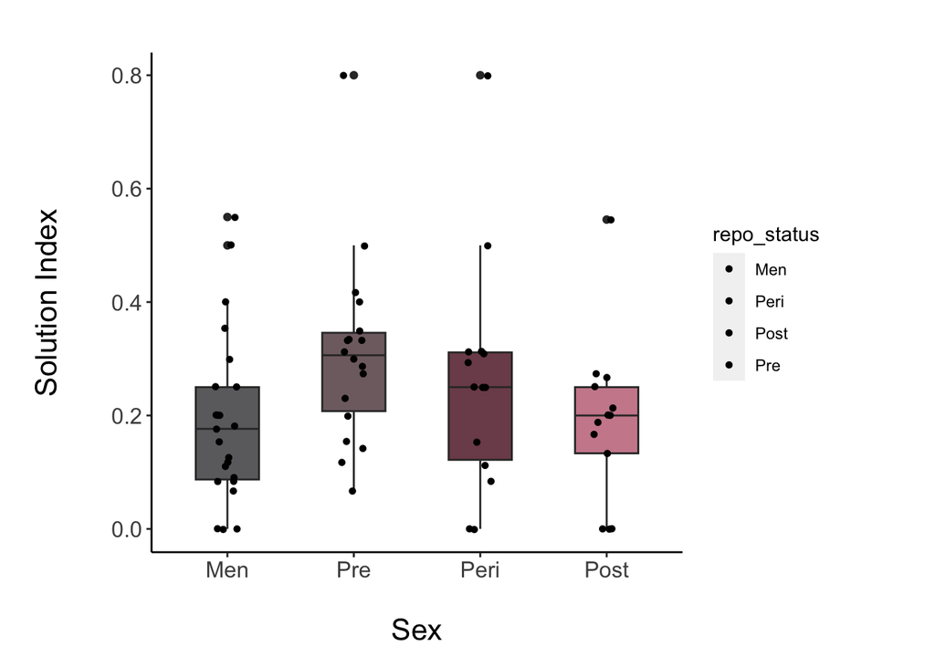

```r
DSP_DSI_DF %>% ggplot(aes(x = factor(repo_status, levels=c("Men", "Pre", "Peri", "Post")), y = dsp_si_true_pct, fill= repo_status)) +
  geom_boxplot(width=0.5,fatten = 1, show.legend = FALSE) +
  geom_point(shape=16, position=position_jitter(0.1)) +
  scale_fill_manual(values=c("#6c6c6e","#7d4c5a", "#CD8A9B","#806d71"))+
  scale_y_continuous(breaks = seq(0, 1, by = 0.2)) +
   xlab("Sex")+
   ylab("Solution Index") +
  theme(axis.title.x = element_text(vjust=- 4, size = 16),
         axis.title.y = element_text(vjust=8, size = 16),
         axis.text.x = element_text(size = 12),
         axis.text.y = element_text(size = 12),
         panel.background =element_blank(),
         axis.line = element_line(colour = "black"),
         plot.margin = margin(1, 2, 1, 1.5, "cm"),
         plot.title = element_text(hjust = 0.5, vjust = 2, size = 16, face="bold" )
 )
```

```r
# ggboxplot(sub_info, x = "REPO", y = "maze_accuracy_pct",
#           color = "REPO",
#           order = c("Male", "Pre", "Peri", "Post"),
#           ylab = "Wayfinding Success", xlab = "Group")
```

# Summarized Results

- There’s really no difference between scan and spatial hormones. FSH is the exact same between spatial and scan. Estradiol is a bit different between them but shouldn’t be too much of a difference. Changes a bit of the significance but not overall relationships.
- I can replicate shuyings one tailed analysies but i don’t know if i can do an actual mediation analysis. When i do a linear regression, nothing is significant.
- CANNOT REPLICATE THIS WITH NEW TRACTOMETRY VERSION: For estradiol, solution index is associated with MD. Shuyings results show that estradiol is associated with more shortcuts but estradiol is not associated with MD based on our linear regression here. So white matter contributes to SI performance, and so does estradiol but estradiol does not impact white matter. Therefore they may be influencing SI performance through different mechanisms.

# Correlational tractography results